# P9 partie 2 - Etude de marché pour l'entreprise "La poule qui chante"

[figure not shown]

**OBJECTIF :** proposer une première analyse des groupements de pays à cibler pour l'exportation de poulets

**ATTENTES :**

- Analyse en Composantes Principales pour visualiser les résultats de l'analyse, comprendre les groupes, les liens entre les variables, les liens entre les individus
- Classification ascendante hiérarchique, avec un dendrogramme comme visualisation
- Clustering des k-means
- Comparaison des résultats avec les deux méthodes de clustering (HAC et k-means)

# 1. Importation du dataset nettoyé précédemment

```python
cd /Users/ahami/Desktop/Formation_OCR/P9_Etude_de_marché_avec_R_ou_Python/data
```

```
C:\Users\ahami\Desktop\Formation_OCR\P9_Etude_de_marché_avec_R_ou_Python\data
```

```python
# Importation des librairies
import pandas as pd
import numpy as np
import matplotlib.pyplot as plt
import seaborn as sns
from functions import *

from sklearn import decomposition, preprocessing
from sklearn.cluster import KMeans, AgglomerativeClustering
from sklearn.metrics import silhouette_score
from scipy.cluster.hierarchy import linkage, fcluster, dendrogram
```

```python
# Importation du dataset
my_data = pd.read_csv('my_data_vf.csv', index_col='Zone', sep=';')
my_data.head()
```

| Zone | Densité de population urbaine | PIB par habitant, ($ PPA internationaux constants de 2017) | Disponibilités protéines moyennes d’origine animale (g/personne/jour) (moyenne sur 3 ans) | Exportations | Importations | Production | Crédits à l'agriculture (millions $US) | Stabilité politique et absence de violence/terrorisme (indice) | % de la population utilisant des infrastructures d'eau basiques | Inflation (%) | Région |
| --- | --- | --- | --- | --- | --- | --- | --- | --- | --- | --- | --- |
| Afghanistan | 24.717446 | 2058.4 | 10.7 | 0.0 | 29.0 | 28.0 | 25.623698 | -2.80 | 66.80 | 6.957529 | Asie |
| Afrique du Sud | 65.511864 | 13860.3 | 35.7 | 63.0 | 514.0 | 1667.0 | 556.747040 | -0.28 | 93.02 | 6.550573 | Afrique |
| Albanie | 60.330445 | 12771.0 | 61.0 | 0.0 | 38.0 | 13.0 | 580.756357 | 0.38 | 96.26 | 5.453396 | Europe |
| Algérie | 71.928469 | 11737.4 | 25.0 | 0.0 | 2.0 | 275.0 | 580.756357 | -0.92 | 95.22 | 5.382061 | Afrique |
| Allemagne | 76.752172 | 53071.5 | 63.0 | 646.0 | 842.0 | 1514.0 | 4471.001945 | 0.59 | 96.86 | 0.416540 | Europe |

## 1.1. Préparation des données

```python
# Préparation des données
X = my_data[my_data.columns[:10]].values
country = my_data.index
header = my_data.columns[:10]
features = my_data.columns
```

```python
# Centrage et Réduction
X_scaled = preprocessing.StandardScaler().fit_transform(X)
df_X_scaled = pd.DataFrame(X_scaled,columns=header)
df_X_scaled.describe().round(4)
```

|  | Densité de population urbaine | PIB par habitant, ($ PPA internationaux constants de 2017) | Disponibilités protéines moyennes d’origine animale (g/personne/jour) (moyenne sur 3 ans) | Exportations | Importations | Production | Crédits à l'agriculture (millions $US) | Stabilité politique et absence de violence/terrorisme (indice) | % de la population utilisant des infrastructures d'eau basiques | Inflation (%) |
| --- | --- | --- | --- | --- | --- | --- | --- | --- | --- | --- |
| count | 232.0000 | 232.0000 | 232.0000 | 232.0000 | 232.0000 | 232.0000 | 232.0000 | 232.0000 | 232.0000 | 232.0000 |
| mean | -0.0000 | -0.0000 | -0.0000 | -0.0000 | -0.0000 | -0.0000 | 0.0000 | 0.0000 | 0.0000 | 0.0000 |
| std | 1.0022 | 1.0022 | 1.0022 | 1.0022 | 1.0022 | 1.0022 | 1.0022 | 1.0022 | 1.0022 | 1.0022 |
| min | -2.7070 | -0.9842 | -1.8385 | -0.2730 | -0.5821 | -0.3838 | -0.6520 | -3.1154 | -3.7302 | -1.4185 |
| 25% | -0.7017 | -0.7551 | -0.7474 | -0.2730 | -0.5387 | -0.3716 | -0.5524 | -0.6038 | -0.3870 | -0.7552 |
| 50% | -0.0016 | -0.2727 | -0.0385 | -0.2629 | -0.3400 | -0.3126 | -0.3661 | 0.0112 | 0.4344 | -0.1163 |
| 75% | 0.7740 | 0.3043 | 0.5140 | 0.0208 | 0.0697 | -0.0667 | -0.1060 | 0.7590 | 0.7410 | 0.4203 |
| max | 2.2098 | 5.1320 | 3.7000 | 10.3464 | 6.0548 | 9.1995 | 9.0996 | 2.1516 | 0.9295 | 6.0718 |

# 2. Analyse exploratoire

## 2.1. Visualisation de la distribution de chaque variable

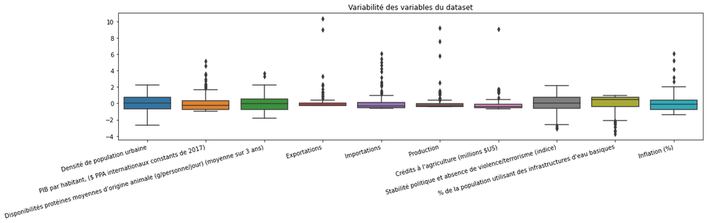

```python
# Boxplot
plt.figure(figsize = (18,4))
chart = sns.boxplot(data = df_X_scaled)
chart.set_xticklabels(chart.get_xticklabels(), rotation=15, horizontalalignment='right')
plt.title('Variabilité des variables du dataset')
plt.savefig('boxplot_P9.png', bbox_inches='tight')
plt.show()
```

## 2.2. Corrélations entre les variables

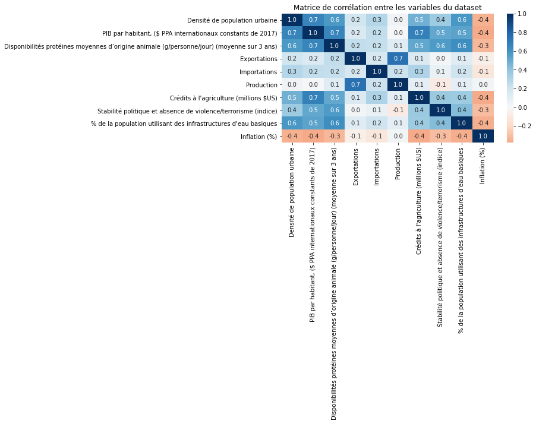

```python
# Matrice de corrélation de Pearson
plt.figure(figsize=(8,4))
sns.heatmap(df_X_scaled.corr(), cmap='RdBu', center=0, annot=True, fmt='.1f',)
plt.title ('Matrice de corrélation entre les variables du dataset')
plt.savefig('matrice_P9.png', bbox_inches='tight')
plt.show()
```

Les plus fortes corrélations entre les variables sont :

- PIB/habitant & Densité de population urbaine avec un coefficient de corrélation positif de 0,7
- PIB/habitant & Disponibilité en protéines animales avec un coefficient de corrélation positif de 0,7
- Crédits attribués à l'agriculture & PIB/habitant avec un coefficient de corrélation positif de 0,7
- Production & Exportations avec un coefficient de corrélation positif de 0,7

### 2.2.1. Éboulis des valeurs propres

Interprétation graphique des composantes et de leur pourcentage de variance associée : avec le critère du Coude, cela permet de définir le nombre de composantes nécessaires pour atteindre un ratio de variance le plus élevé tout en conservant un nombre réduit de composantes.

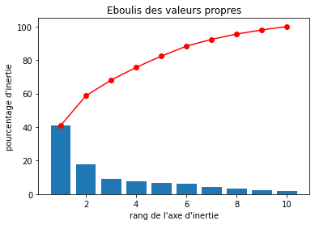

```python
# Sélection de 10 composantes correspondant aux 10 variables du dataset
num_components  = 10

# Création du modèle PCA
pca = decomposition.PCA(n_components=num_components)

# Entrainement du modèle sur les données standardisées
model = pca.fit(X_scaled)

# Eboulis des valeurs propres
display_scree_plot(pca)
```

### 2.2.2. Analyse de la variance

Étude de la variance expliquée pour chaque composante

```python
# Part de variance expliquée pour chacune des 10 composantes principales
display(pca.explained_variance_ratio_.round(3))

# Variance cumulée entre les 10 composantes principales
display(pca.explained_variance_ratio_.cumsum().round(3))
```

```
array([0.409, 0.177, 0.093, 0.076, 0.067, 0.06 , 0.041, 0.032, 0.024,
       0.021])
```

```
array([0.409, 0.587, 0.68 , 0.756, 0.823, 0.883, 0.923, 0.955, 0.979,
       1.   ])
```

## 2.3. Cercle des corrélations

Etude des liaisons entre les variables : par un nuage des variables dans un espace à 𝑛 dimensions dans lequel il est placé autant de dimensions que d’individus 𝑛 et autant de points que de variables p

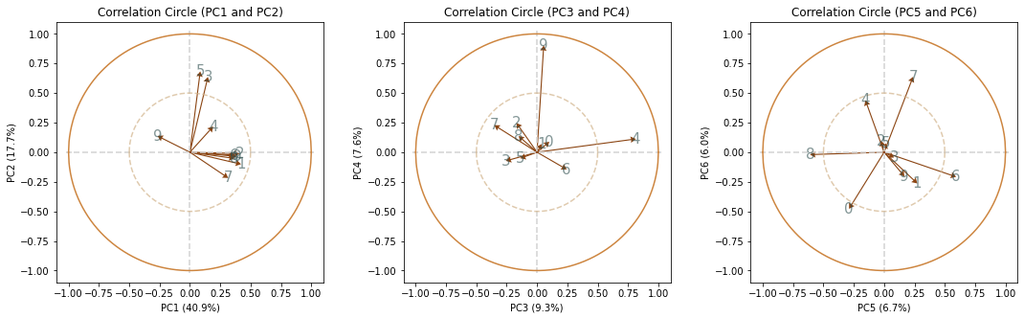

```python
# Génération des cercles de corrélations
pcs = pca.components_

df_num = pd.DataFrame(data=X_scaled)
nb = df_num.columns #numéro de variable

def display_circles(pcs, n_comp, pca, axis_ranks, labels=None, label_rotation=0, lims=None):
    """Display correlation circles, one for each factorial plane"""

    # Initialise the matplotlib figure
    fig, ax = plt.subplots(1,3, figsize=(18,5))
    plt.subplots_adjust(wspace=0.3)

    # For each factorial plane
    for k, (d1, d2) in enumerate(axis_ranks):
        if d2 < n_comp:

            # Determine the limits of the chart
            if lims is not None :
                xmin, xmax, ymin, ymax = lims
            elif pcs.shape[1] < 30 :
                xmin, xmax, ymin, ymax = -1, 1, -1, 1
            else :
                xmin, xmax, ymin, ymax = min(pcs[d1,:]), max(pcs[d1,:]), min(pcs[d2,:]), max(pcs[d2,:])

            # Add arrows
            # If there are more than 30 arrows, we do not display the triangle at the end
            if pcs.shape[1] < 30 :
                ax[k].quiver(np.zeros(pcs.shape[1]), np.zeros(pcs.shape[1]),
                             pcs[d1,:], pcs[d2,:], angles='xy', scale_units='xy',
                             scale=1, color="saddlebrown", headwidth=6, width=0.004,)
            else:
                lines = [[[0,0],[x,y]] for x,y in pcs[[d1,d2]].T]
                ax.add_collection(LineCollection(lines, axes=ax, alpha=.1, color='black'))

            # Display variable names
            if labels is not None:
                for i,(x, y) in enumerate(pcs[[d1,d2]].T):
                    if x >= xmin and x <= xmax and y >= ymin and y <= ymax :
                        ax[k].text(x, y, labels[i], fontsize='15', ha='center', va='center',
                                 rotation=label_rotation, color="darkslategrey", alpha=0.6)

            #Plot circle
            x=np.linspace(start=-1,stop=1,num=500)
            y_positive=lambda x: np.sqrt(1-x**2)
            y_negative=lambda x: -np.sqrt(1-x**2)
            ax[k].plot(x,list(map(y_positive, x)), color='peru')
            ax[k].plot(x,list(map(y_negative, x)),color='peru')

            #Plot smaller circle
            x=np.linspace(start=-0.5,stop=0.5,num=500)
            y_positive=lambda x: np.sqrt(0.5**2-x**2)
            y_negative=lambda x: -np.sqrt(0.5**2-x**2)
            ax[k].plot(x,list(map(y_positive, x)), color='tan', alpha=0.7, ls='--')
            ax[k].plot(x,list(map(y_negative, x)),color='tan', alpha=0.7, ls='--')

            #Create broken lines
            x=np.linspace(start=-1,stop=1,num=30)
            ax[k].scatter(x,[0]*len(x), marker='_',color='lightgrey')
            ax[k].scatter([0]*len(x), x, marker='|',color='lightgrey')

            # Label the axes, with the percentage of variance explained
            ax[k].set_xlabel('PC{} ({}%)'.format(d1+1, round(100*pca.explained_variance_ratio_[d1],1)))
            ax[k].set_ylabel('PC{} ({}%)'.format(d2+1, round(100*pca.explained_variance_ratio_[d2],1)))

            ax[k].set_title("Correlation Circle (PC{} and PC{})".format(d1+1, d2+1))


# sur les 3 premiers plans factoriels
display_circles(pcs, num_components, pca, [(0,1), (2,3), (4,5)], labels = nb)
```

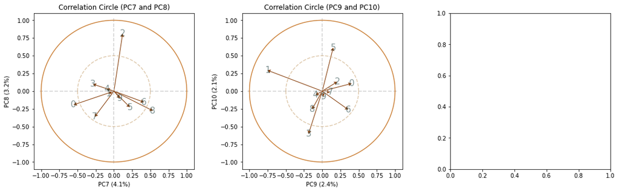

```python
# sur les 2 plans factoriels restants
display_circles(pcs, num_components, pca, [(6,7), (8,9)], labels = nb)
```

```python
# Création d'une table des correspondances pour relier les numéros à leurs variables
print(pd.DataFrame(data={'Numéro' : nb, 'Intitulé' : header}))
```

```
   Numéro                                           Intitulé
0       0                      Densité de population urbaine
1       1  PIB par habitant, ($ PPA internationaux consta...
2       2  Disponibilités protéines moyennes d’origine an...
3       3                                       Exportations
4       4                                       Importations
5       5                                         Production
6       6             Crédits à l'agriculture (millions $US)
7       7  Stabilité politique et absence de violence/ter...
8       8  % de la population utilisant des infrastructur...
9       9                                      Inflation (%)
```

**📌Interprétation du Cercle des Corrélations : étude des liaisons entre les variables**

➡️ sur le 1er plan factoriel : 0, 1, 2, 6, 8 : Densité urbaine, PIB/habitant, Disponibilités protéines, Crédits à l'agriculture, Accès à l'eau 3, 5 : Exportations et Production

➡️ sur le 2e plan factoriel : 2, 7, 8 : Disponibilités protéines, Stabilité politique Accès à l'eau 3, 5 : Exportations et Production

➡️ sur le 3e plan factoriel : 1, 9 : PIB/habitant, Inflation

➡️ sur le 4e plan factoriel : 6, 8 : Crédits à l'agriculture, Accès à l'eau

➡️ sur le 5e plan factoriel : 0, 2, Densité urbaine, Disponibilités protéines

**📌 Interprétation du Cercle des Corrélations : étude corrélations entre les variables initiales et les composantes principales**

➡️ Le 1er plan factoriel avec PC1 et PC2 représente 58.6% de la variance du dataset original, sur lequel : les variables Exportations et Production sont fortement corrélées entre elles. Ces 2 variables sont aussi très fortement corrélées positivement à PC2.

➡️ Le 2e plan factoriel avec PC3 et PC4 représente 16.9% de la variance du dataset original : La variable "Importation" est fortement corrélée à PC3 et la variable "Inflation" est fortement corrélée à PC4.

➡️ Le 3e plan factoriel avec PC5 et PC6 représente 12.7% de la variance du dataset original.

➡️ Le 4e plan factoriel avec PC7 et PC8 représente 7.3% de la variance du dataset original avec : La variable "Disponibilité protéines" est corrélée positivement à PC8

➡️ Le 5e plan factoriel avec PC9 et PC10 représente 4.5% de la variance du daset original avec : La variable "PIB/habitant" est corrélée négativement à PC9.

📌Interprétation des 6 Composantes Principales qui représentent près de 90% de la variance du dataset original

✅PC1 : Pays riches, stables et urbains

✅PC2 : Pays producteurs et exportateurs

✅PC3 : Pays importateurs mais peu stables

✅PC4 : Pays à forte inflation

✅PC5 : Pays avec des crédits pour l'agriculture mais peu d'accès à l'eau

✅PC6 : Pays importateurs et stables

```python
# Dataframe pour les liaisons entre les variables : coefficient de chaque variable pour former une composante principale
liaisons = pd.DataFrame(pca.components_.T, columns=['PC%s' % _ for _ in range(1,11)], index=header).copy()
liaisons
```

|  | PC1 | PC2 | PC3 | PC4 | PC5 | PC6 | PC7 | PC8 | PC9 | PC10 |
| --- | --- | --- | --- | --- | --- | --- | --- | --- | --- | --- |
| Densité de population urbaine | 0.386578 | -0.035052 | 0.101585 | 0.088375 | -0.289349 | -0.478260 | -0.553655 | -0.193177 | 0.404110 | 0.107647 |
| PIB par habitant, ($ PPA internationaux constants de 2017) | 0.421494 | -0.101071 | 0.038945 | 0.069728 | 0.273451 | -0.263711 | -0.076843 | -0.033745 | -0.753279 | 0.294884 |
| Disponibilités protéines moyennes d’origine animale (g/personne/jour) (moyenne sur 3 ans) | 0.411133 | -0.011165 | -0.169341 | 0.247041 | -0.024307 | 0.096447 | 0.119160 | 0.810490 | 0.206443 | 0.132415 |
| Exportations | 0.148228 | 0.636227 | -0.256854 | -0.073176 | 0.082076 | -0.045010 | -0.288923 | 0.099075 | -0.188214 | -0.603685 |
| Importations | 0.191502 | 0.217233 | 0.814928 | 0.112105 | -0.154227 | 0.439145 | -0.100828 | 0.032480 | -0.092197 | -0.055738 |
| Production | 0.084988 | 0.683357 | -0.138005 | -0.051306 | 0.014363 | 0.075543 | 0.218191 | -0.226231 | 0.150879 | 0.613725 |
| Crédits à l'agriculture (millions $US) | 0.364407 | -0.024182 | 0.245048 | -0.145138 | 0.593373 | -0.208113 | 0.412152 | -0.156222 | 0.357486 | -0.260838 |
| Stabilité politique et absence de violence/terrorisme (indice) | 0.315488 | -0.217686 | -0.352396 | 0.228632 | 0.238604 | 0.637244 | -0.264454 | -0.362335 | 0.110643 | -0.012200 |
| % de la population utilisant des infrastructures d'eau basiques | 0.366747 | -0.052375 | -0.151937 | 0.136453 | -0.610717 | -0.020096 | 0.534470 | -0.277074 | -0.140046 | -0.256182 |
| Inflation (%) | -0.266785 | 0.136985 | 0.055177 | 0.902101 | 0.167880 | -0.205052 | 0.081540 | -0.100679 | 0.017530 | -0.076862 |

```python
# Liaison des composantes principales avec les valeurs absolues des 3 variables les mieux représentées
for PC in liaisons.columns:
    df_representation = liaisons[PC].sort_values(ascending=False, key=abs).head(3)

    print('Variables qui contribuent le plus à', PC, '(valeurs absolues): \n',df_representation, "\n", '-'*50, '\n')
```

```
Variables qui contribuent le plus à PC1 (valeurs absolues):
 PIB par habitant, ($ PPA internationaux constants de 2017)                                   0.421494
Disponibilités protéines moyennes d’origine animale (g/personne/jour) (moyenne sur 3 ans)    0.411133
Densité de population urbaine                                                                0.386578
Name: PC1, dtype: float64
 --------------------------------------------------

Variables qui contribuent le plus à PC2 (valeurs absolues):
 Production                                                        0.683357
Exportations                                                      0.636227
Stabilité politique et absence de violence/terrorisme (indice)   -0.217686
Name: PC2, dtype: float64
 --------------------------------------------------

Variables qui contribuent le plus à PC3 (valeurs absolues):
 Importations                                                      0.814928
Stabilité politique et absence de violence/terrorisme (indice)   -0.352396
Exportations                                                     -0.256854
Name: PC3, dtype: float64
 --------------------------------------------------

Variables qui contribuent le plus à PC4 (valeurs absolues):
 Inflation (%)                                                                                0.902101
Disponibilités protéines moyennes d’origine animale (g/personne/jour) (moyenne sur 3 ans)    0.247041
Stabilité politique et absence de violence/terrorisme (indice)                               0.228632
Name: PC4, dtype: float64
 --------------------------------------------------

Variables qui contribuent le plus à PC5 (valeurs absolues):
 % de la population utilisant des infrastructures d'eau basiques   -0.610717
Crédits à l'agriculture (millions $US)                             0.593373
Densité de population urbaine                                     -0.289349
Name: PC5, dtype: float64
 --------------------------------------------------

Variables qui contribuent le plus à PC6 (valeurs absolues):
 Stabilité politique et absence de violence/terrorisme (indice)    0.637244
Densité de population urbaine                                    -0.478260
Importations                                                      0.439145
Name: PC6, dtype: float64
```

[output cut: 14 more lines]

```
 --------------------------------------------------

Variables qui contribuent le plus à PC9 (valeurs absolues):
 PIB par habitant, ($ PPA internationaux constants de 2017)   -0.753279
Densité de population urbaine                                 0.404110
Crédits à l'agriculture (millions $US)                        0.357486
Name: PC9, dtype: float64
 --------------------------------------------------

Variables qui contribuent le plus à PC10 (valeurs absolues):
 Production                                                    0.613725
Exportations                                                 -0.603685
PIB par habitant, ($ PPA internationaux constants de 2017)    0.294884
Name: PC10, dtype: float64
 --------------------------------------------------
```

## 2.4. Heatmap sur des données normalisées

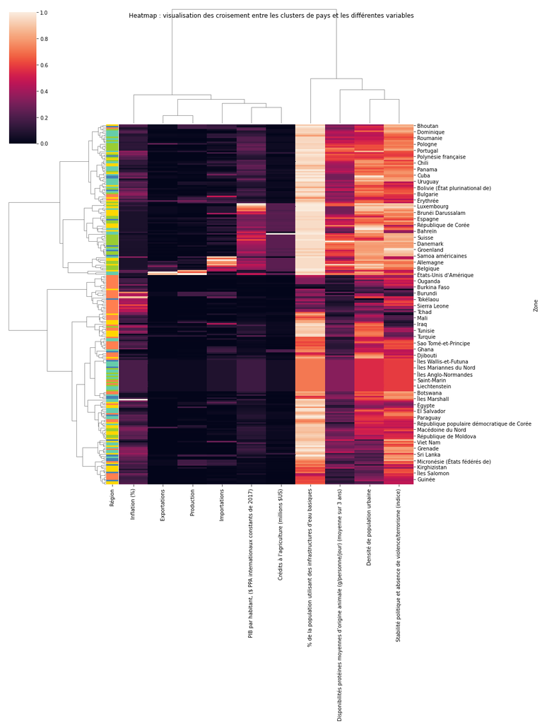

```python
# Heatmap avec normalisation en fonction des colonnes

region_color = my_data["Région"].map({'Asie':'gold',
                                     'Afrique':'coral',
                                     'Europe':'yellowgreen',
                                     'Amériques':'mediumaquamarine',
                                     'Océanie':'steelblue'})

clm = sns.clustermap(my_data.iloc[:,:-1], figsize=(15,20), dendrogram_ratio=0.25, standard_scale=1, method='ward', metric='euclidean', row_colors=region_color, col_cluster=True)
clm.fig.suptitle('Heatmap : visualisation des croisement entre les clusters de pays et les différentes variables')

plt.show()

# sauvegarder image
clm.savefig('heatmap.jpg',  format='png', orientation="landscape")
```

## 2.5. Plan Factoriel

```python
# Projection des individus sur les axes principaux
X_projected = pca.transform(X_scaled)
```

```python
variabilite  = pd.DataFrame(X_projected, columns=['PC%s' % _ for _ in range(1,11)], index=country)
variabilite
```

| Zone | PC1 | PC2 | PC3 | PC4 | PC5 | PC6 | PC7 | PC8 | PC9 | PC10 |
| --- | --- | --- | --- | --- | --- | --- | --- | --- | --- | --- |
| Afghanistan | -3.733381 | 0.479525 | 1.041420 | -0.946758 | 0.438826 | -1.148586 | 0.361380 | 0.887840 | -0.486062 | -0.017908 |
| Afrique du Sud | 0.286387 | 0.851720 | 2.080360 | 0.709780 | -1.025690 | 0.972215 | -0.118195 | -0.078941 | -0.010503 | 0.021443 |
| Albanie | 0.495654 | -0.590425 | -0.756023 | 0.738130 | -0.609522 | 0.384081 | 0.318295 | 0.839333 | 0.456416 | -0.084594 |
| Algérie | -0.648986 | -0.242365 | -0.055276 | -0.090740 | -0.973777 | -1.028942 | 0.163139 | -0.372396 | 0.190018 | -0.182227 |
| Allemagne | 4.016615 | 1.501937 | 3.279417 | 0.174175 | 0.109497 | 1.637305 | -0.357858 | 0.592530 | -0.654458 | -0.720677 |
| ... | ... | ... | ... | ... | ... | ... | ... | ... | ... | ... |
| Îles Salomon | -1.908088 | -0.458415 | -0.537132 | -0.707763 | 0.246135 | 1.066419 | 0.308391 | -0.385200 | -0.344491 | -0.334613 |
| Îles Turques-et-Caïques | -0.175836 | 0.014201 | -0.001277 | 0.009631 | 0.188824 | 0.009374 | -0.270820 | 0.174165 | 0.007946 | 0.053397 |
| Îles Vierges américaines | -0.175836 | 0.014201 | -0.001277 | 0.009631 | 0.188824 | 0.009374 | -0.270820 | 0.174165 | 0.007946 | 0.053397 |
| Îles Vierges britanniques | -0.175836 | 0.014201 | -0.001277 | 0.009631 | 0.188824 | 0.009374 | -0.270820 | 0.174165 | 0.007946 | 0.053397 |
| Îles Wallis-et-Futuna | -0.175836 | 0.014201 | -0.001277 | 0.009631 | 0.188824 | 0.009374 | -0.270820 | 0.174165 | 0.007946 | 0.053397 |

232 rows × 10 columns

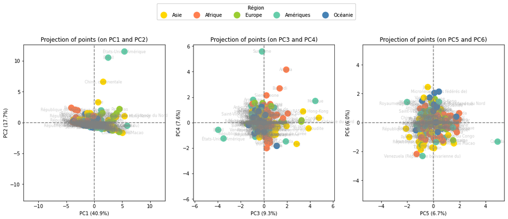

```python
# Display a scatter plot of the data points in this new vector space

from matplotlib.lines import Line2D

def display_factorial_planes(X_projected, n_comp, pca, axis_ranks, labels=None, alpha=1, illustrative_var=None, legend=None):
    '''Display a scatter plot on a factorial plane, one for each factorial plane'''

    colors = {'Asie':'gold', 'Afrique':'coral', 'Europe':'yellowgreen', 'Amériques':'mediumaquamarine', 'Océanie':'steelblue'}

    # Initialise the matplotlib figure
    fig, ax = plt.subplots(1,3, figsize=(18,6))
    plt.subplots_adjust(hspace=1)

    # For each factorial plane
    for a, (d1, d2) in enumerate(axis_ranks):
        if d2 < n_comp:

            # Display the points
            if illustrative_var is None:
                ax[a].scatter(variabilite.iloc[:, d1], variabilite.iloc[:, d2],
                              c=my_data['Région'].map(colors), alpha=alpha, s=150)
            elif illustrative_var == 'KMeans':
                sns.scatterplot(ax=ax[a], x=df_clustered.iloc[:, d1], y=df_clustered.iloc[:, d2], hue= df_clustered['cluster_KMeans'], palette=sns.color_palette("Set1", as_cmap=True))
                ax[a].legend()
                fig.suptitle(f"K-Means : Projection des {X_projected.shape[0]} individus sur les plans factoriels répartis en {len(centroid)} centres", fontsize=16)

            elif illustrative_var == 'HAC':
                sns.scatterplot(ax=ax[a], x=df_clustered.iloc[:, d1], y=df_clustered.iloc[:, d2], hue= df_clustered['cluster_HAC'],palette=sns.color_palette("Set1", as_cmap=True))
                ax[a].legend()
                fig.suptitle(f"Hierarchical Agglomerative Clustering : Projection des {X_projected.shape[0]} individus sur les plans factoriels répartis en {len(centroid)} centres", fontsize=16)

            # Display the labels on the points
            if labels is not None:
                for i,(x,y) in enumerate(X_projected[:,[d1,d2]]):
                    ax[a].text(x, y, labels[i], fontsize='8', ha='center',va='center', alpha=0.4, c='grey')

            # add a legend
            if legend == 'Région':
                handles = [Line2D([0], [0], marker='o', color='w', markerfacecolor=v, label=k,
                              markersize=15) for k, v in colors.items()]
                fig.legend(title='Région', handles=handles, borderaxespad=0,
                      bbox_to_anchor=(0, 1, 1, 0), loc="lower center",  ncol=5)

            # Define the limits of the chart
            boundary = np.max(np.abs(X_projected[:, [d1,d2]])) * 1.1
            ax[a].set_xlim([-boundary,boundary])
            ax[a].set_ylim([-boundary,boundary])

            # Display grid lines
            ax[a].plot([-100, 100], [0, 0], color='grey', ls='--')
            ax[a].plot([0, 0], [-100, 100], color='grey', ls='--')

            # Label the axes, with the percentage of variance explained
            ax[a].set_xlabel('PC{} ({}%)'.format(d1+1, round(100*pca.explained_variance_ratio_[d1],1)))
            ax[a].set_ylabel('PC{} ({}%)'.format(d2+1, round(100*pca.explained_variance_ratio_[d2],1)))

            ax[a].set_title("Projection of points (on PC{} and PC{})".format(d1+1, d2+1))

display_factorial_planes(X_projected, num_components, pca, [(0,1), (2,3), (4,5)], labels=country, legend='Région')
```

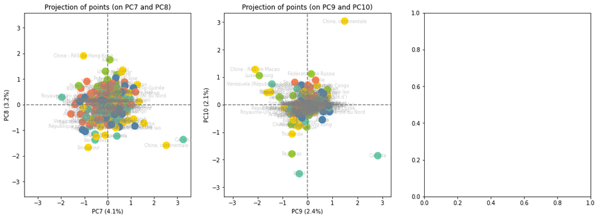

```python
display_factorial_planes(X_projected, num_components, pca, [(6,7), (8,9)], labels=country, legend='Continent')
```

## 2.6. Analyse de la représentation des variables sur les plans factoriels

En partant de l'analyse des composantes comme suit :

✅PC1 : Pays riches, stables et urbains

✅PC2 : Pays producteurs et exportateurs

✅PC3 : Pays importateurs mais peu stables

✅PC4 : Pays à forte inflation

✅PC5 : Pays avec des crédits pour l'agriculture mais peu d'accès à l'eau

✅PC6 : Pays importateurs et stables

```python
#stockage du mode commun des composantes principales pour les renommer
PC_name = ['Pays riches, stables et urbains', 'Pays producteurs et exportateurs', 'Pays importateurs mais peu stables','Pays à forte inflation',"Pays avec des crédits pour l'agriculture mais peu d'accès à l'eau", "Pays importateurs et stables"]
```

```python
PC_pays = variabilite.iloc[:,:6].copy()
PC_pays.columns=PC_name

# Liaison des composantes principales avec les valeurs absolues des 5 variables les mieux représentées
for PC in PC_pays.columns:
    PC_pays_list = PC_pays[PC].sort_values(ascending=False, key=abs).head(5)

    print('Liste des 5', PC, ': \n',PC_pays_list, '(valeurs absolues): \n', '-'*50, '\n')
```

```
Liste des 5 Pays riches, stables et urbains :
 Zone
Canada                      5.916427
Chine - RAS de Hong-Kong    5.433219
États-Unis d'Amérique       5.416828
Chine - RAS de Macao        5.071112
Pays-Bas                    4.532213
Name: Pays riches, stables et urbains, dtype: float64 (valeurs absolues):
 --------------------------------------------------

Liste des 5 Pays producteurs et exportateurs :
 Zone
États-Unis d'Amérique    11.521990
Brésil                   10.529936
Chine, continentale       6.609401
Chine                     3.281888
Burundi                   2.394003
Name: Pays producteurs et exportateurs, dtype: float64 (valeurs absolues):
 --------------------------------------------------

Liste des 5 Pays importateurs mais peu stables :
 Zone
Japon                    4.787298
Mexique                  4.474694
Brésil                  -3.963415
Arabie saoudite          3.892190
États-Unis d'Amérique   -3.500663
Name: Pays importateurs mais peu stables, dtype: float64 (valeurs absolues):
 --------------------------------------------------

Liste des 5 Pays à forte inflation :
 Zone
Suriname        5.580932
Angola          4.157761
Burundi         2.683804
Sierra Leone    2.134253
Togo           -2.014040
Name: Pays à forte inflation, dtype: float64 (valeurs absolues):
 --------------------------------------------------

Liste des 5 Pays avec des crédits pour l'agriculture mais peu d'accès à l'eau :
 Zone
Canada     4.920261
Iraq      -2.097188
Mexique   -2.021459
Rwanda     1.976720
Niger      1.941401
Name: Pays avec des crédits pour l'agriculture mais peu d'accès à l'eau, dtype: float64 (valeurs absolues):
 --------------------------------------------------

Liste des 5 Pays importateurs et stables :
 Zone
Japon                                     2.457816
Venezuela (République bolivarienne du)   -2.319543
Libye                                    -2.179173
Micronésie (États fédérés de)             2.140728
Samoa                                     2.047649
Name: Pays importateurs et stables, dtype: float64 (valeurs absolues):
 --------------------------------------------------
```

```python
# Liaison des composantes principales avec les valeurs des 5 pays les mieux représentées positivement
for PC in PC_pays.columns:
    PC_pays_list_pos = PC_pays[PC].sort_values(ascending=False).head(5)

    print('Liste des 5', PC, ': \n',PC_pays_list_pos, "(valeurs): \n", '-'*50, '\n')
```

```
Liste des 5 Pays riches, stables et urbains :
 Zone
Canada                      5.916427
Chine - RAS de Hong-Kong    5.433219
États-Unis d'Amérique       5.416828
Chine - RAS de Macao        5.071112
Pays-Bas                    4.532213
Name: Pays riches, stables et urbains, dtype: float64 (valeurs):
 --------------------------------------------------

Liste des 5 Pays producteurs et exportateurs :
 Zone
États-Unis d'Amérique    11.521990
Brésil                   10.529936
Chine, continentale       6.609401
Chine                     3.281888
Burundi                   2.394003
Name: Pays producteurs et exportateurs, dtype: float64 (valeurs):
 --------------------------------------------------

Liste des 5 Pays importateurs mais peu stables :
 Zone
Japon                       4.787298
Mexique                     4.474694
Arabie saoudite             3.892190
Chine - RAS de Hong-Kong    3.412325
Allemagne                   3.279417
Name: Pays importateurs mais peu stables, dtype: float64 (valeurs):
 --------------------------------------------------

Liste des 5 Pays à forte inflation :
 Zone
Suriname        5.580932
Angola          4.157761
Burundi         2.683804
Sierra Leone    2.134253
Argentine       1.785829
Name: Pays à forte inflation, dtype: float64 (valeurs):
 --------------------------------------------------

Liste des 5 Pays avec des crédits pour l'agriculture mais peu d'accès à l'eau :
 Zone
Canada        4.920261
Rwanda        1.976720
Niger         1.941401
Madagascar    1.905644
Angola        1.795680
Name: Pays avec des crédits pour l'agriculture mais peu d'accès à l'eau, dtype: float64 (valeurs):
 --------------------------------------------------

Liste des 5 Pays importateurs et stables :
 Zone
Japon                            2.457816
Micronésie (États fédérés de)    2.140728
Samoa                            2.047649
Tonga                            1.725660
Viet Nam                         1.722483
Name: Pays importateurs et stables, dtype: float64 (valeurs):
 --------------------------------------------------
```

## 2.7 Paramétrage du nombre de composantes pour le clustering

```python
#reparamétrage du modèle PCA sur 6 composantes
pca = decomposition.PCA(n_components=6)
model = pca.fit(X_scaled)
```

# 3. Clustering K-Means

## 3.1. Choix du nombre de clusters

Test de détermination de la valeur optimale de K, choix de la taille de cluster la plus appropriée

```python
# Elbow Method
WCSS = [] # within-cluster sums of squares
for k in range (1,10):
    km = KMeans(n_clusters = k, init = "k-means++", random_state = 10)
    km.fit(X_scaled)
    WCSS.append(km.inertia_)

# Coefficient de Silhouette
silhouette_coefficients = []
for k in range(2, 10):
    kmeans = KMeans(n_clusters=k, n_init=10, init='k-means++')
    kmeans.fit(X_scaled)
    score = silhouette_score(X_scaled, kmeans.labels_)
    silhouette_coefficients.append(score)
```

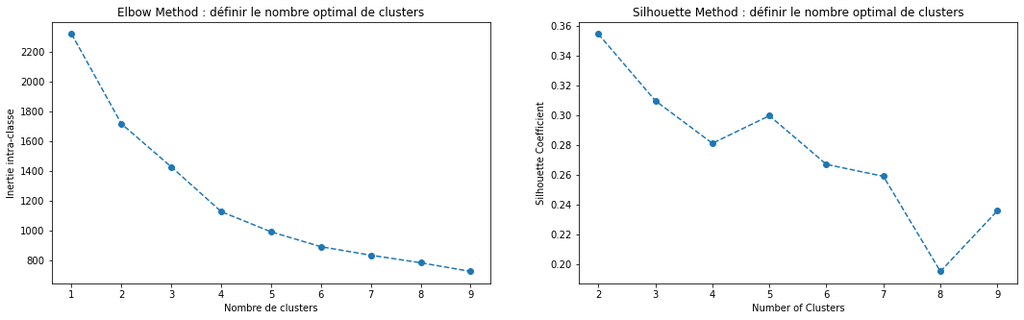

```python
fig = plt.figure(figsize=(18, 5))

# affichage des distorsions et sélection du nombre optimal de cluster avec la Elbow Method
ax1 = fig.add_subplot(121)
ax1.plot(range(1,10), WCSS, marker='o', linestyle='--')
ax1.set_xticks(range(1, 10))
ax1.set_xlabel('Nombre de clusters')
ax1.set_ylabel('Inertie intra-classe')
ax1.set_title('Elbow Method : définir le nombre optimal de clusters')

# affichage Silouhette Method
ax2 = fig.add_subplot(122)
ax2.plot(range(2, 10), silhouette_coefficients, marker='o', linestyle='--')
ax2.set_xticks(range(2, 10))
ax2.set_xlabel("Number of Clusters")
ax2.set_ylabel("Silhouette Coefficient")
ax2.set_title('Silhouette Method : définir le nombre optimal de clusters')

plt.show()
```

## 3.2. Initialisation du modèle K-Means avec 4 clusters

```python
#implémentation de l'algorithme K-Means avec le nombre optimal de clusters sur les données initiales centrées et réduites
km = KMeans(n_clusters=4)
km.fit(X_scaled)
```

```
KMeans(n_clusters=4)
```

```python
#Analyse des clusters du K-Means
print(f"Somme des distances entre les points d'un cluster et son centroïd : {round(km.inertia_,2)}\nNombre d'itérations requises pour couvrir la plage : {km.n_iter_}")
```

```
Somme des distances entre les points d'un cluster et son centroïd : 1140.05
Nombre d'itérations requises pour couvrir la plage : 5
```

```python
# Afficher les clusters KMeans sur les données brutes centrées et réduites
X_scaled_clustered = pd.DataFrame(X_scaled, columns=header, index=country)
X_scaled_clustered['cluster_KMeans'] = km.predict(X_scaled)
X_scaled_clustered.head()
```

| Zone | Densité de population urbaine | PIB par habitant, ($ PPA internationaux constants de 2017) | Disponibilités protéines moyennes d’origine animale (g/personne/jour) (moyenne sur 3 ans) | Exportations | Importations | Production | Crédits à l'agriculture (millions $US) | Stabilité politique et absence de violence/terrorisme (indice) | % de la population utilisant des infrastructures d'eau basiques | Inflation (%) | cluster_KMeans |
| --- | --- | --- | --- | --- | --- | --- | --- | --- | --- | --- | --- |
| Afghanistan | -1.585521 | -0.921498 | -1.412027 | -0.272957 | -0.402098 | -0.371550 | -0.638879 | -2.963721 | -1.906848 | 0.507212 | 2 |
| Afrique du Sud | 0.265481 | -0.345740 | -0.027408 | -0.114534 | 2.609037 | 0.345208 | -0.366140 | -0.232646 | 0.402737 | 0.420282 | 0 |
| Albanie | 0.030380 | -0.398882 | 1.373827 | -0.272957 | -0.346221 | -0.378110 | -0.353811 | 0.482635 | 0.688132 | 0.185911 | 0 |
| Algérie | 0.556628 | -0.449306 | -0.620025 | -0.272957 | -0.569728 | -0.263534 | -0.353811 | -0.926252 | 0.596523 | 0.170673 | 0 |
| Allemagne | 0.775498 | 1.567184 | 1.484596 | 1.351500 | 4.645433 | 0.278299 | 1.643888 | 0.710225 | 0.740983 | -0.890022 | 1 |

```python
# Création d'un dataframe sur les données projetées du PCA à 6 composantes pca.transform(X_scaled)
df_clustered = variabilite.iloc[:,:-4].copy()

# Création d'une variable avec le numéro de cluster attribué à chaque individu
df_clustered['cluster_KMeans'] = km.labels_
df_clustered.head()
```

| Zone | PC1 | PC2 | PC3 | PC4 | PC5 | PC6 | cluster_KMeans |
| --- | --- | --- | --- | --- | --- | --- | --- |
| Afghanistan | -3.733381 | 0.479525 | 1.041420 | -0.946758 | 0.438826 | -1.148586 | 2 |
| Afrique du Sud | 0.286387 | 0.851720 | 2.080360 | 0.709780 | -1.025690 | 0.972215 | 0 |
| Albanie | 0.495654 | -0.590425 | -0.756023 | 0.738130 | -0.609522 | 0.384081 | 0 |
| Algérie | -0.648986 | -0.242365 | -0.055276 | -0.090740 | -0.973777 | -1.028942 | 0 |
| Allemagne | 4.016615 | 1.501937 | 3.279417 | 0.174175 | 0.109497 | 1.637305 | 1 |

# 4. Classification Ascendante Hiérarchique ou Hierarchical Agglomerative Clustering (HAC)

## 4.1. Choix du nombre de clusters

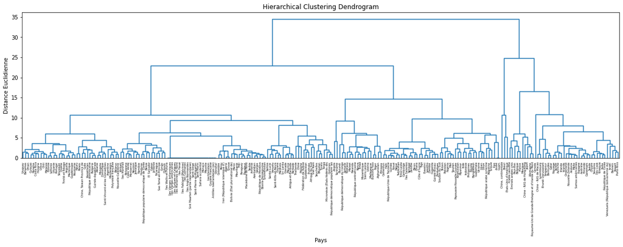

```python
# Create a hierarchical clustering model
hc = AgglomerativeClustering(affinity='euclidean', linkage='ward', compute_full_tree=True)

# Définir la distance matrice des liens
Z = linkage(X_scaled, method = 'ward', metric = 'euclidean')

# Affichage du dendrogramme
plt.figure(1, figsize = (20,5))
dn = dendrogram(Z, labels = country, orientation = "top", color_threshold=0)
plt.title('Hierarchical Clustering Dendrogram')
plt.xlabel('Pays')
plt.ylabel('Distance Euclidienne')
plt.show()
```

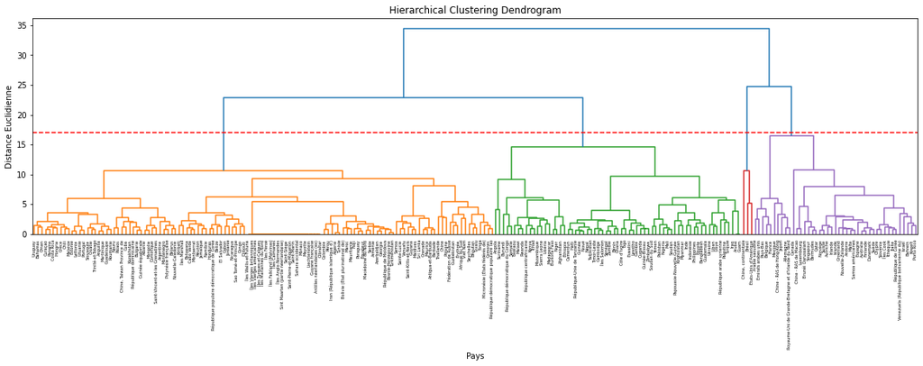

```python
# Choix de 4 clusters avec une distance euclidienne de 17
plt.figure(1, figsize = (20,5))
dend = dendrogram(Z, labels = country, orientation = "top", color_threshold=17)
plt.axhline(y=17, color='r',linestyle='dashed')
plt.title('Hierarchical Clustering Dendrogram')
plt.xlabel('Pays')
plt.ylabel('Distance Euclidienne')
plt.show()
```

## 4.2. Initialisation du modèle HAC avec 4 clusters

```python
# Create a hierarchical clustering model
hc = AgglomerativeClustering(affinity='euclidean', linkage='ward', compute_full_tree=True)

# Fit the data to the model and determine which clusters each data point belongs to:
hc.set_params(n_clusters=4)
cluster_hc = hc.fit_predict(X_scaled)
```

## 4.3. Ajout des Clusters HAC dans les DataFrames de données originales et des PCA

```python
# Afficher les clusters HAC sur les données brutes centrées et réduites
X_scaled_clustered['cluster_HAC'] = cluster_hc
X_scaled_clustered.head()
```

| Zone | Densité de population urbaine | PIB par habitant, ($ PPA internationaux constants de 2017) | Disponibilités protéines moyennes d’origine animale (g/personne/jour) (moyenne sur 3 ans) | Exportations | Importations | Production | Crédits à l'agriculture (millions $US) | Stabilité politique et absence de violence/terrorisme (indice) | % de la population utilisant des infrastructures d'eau basiques | Inflation (%) | cluster_KMeans | cluster_HAC |
| --- | --- | --- | --- | --- | --- | --- | --- | --- | --- | --- | --- | --- |
| Afghanistan | -1.585521 | -0.921498 | -1.412027 | -0.272957 | -0.402098 | -0.371550 | -0.638879 | -2.963721 | -1.906848 | 0.507212 | 2 | 1 |
| Afrique du Sud | 0.265481 | -0.345740 | -0.027408 | -0.114534 | 2.609037 | 0.345208 | -0.366140 | -0.232646 | 0.402737 | 0.420282 | 0 | 3 |
| Albanie | 0.030380 | -0.398882 | 1.373827 | -0.272957 | -0.346221 | -0.378110 | -0.353811 | 0.482635 | 0.688132 | 0.185911 | 0 | 3 |
| Algérie | 0.556628 | -0.449306 | -0.620025 | -0.272957 | -0.569728 | -0.263534 | -0.353811 | -0.926252 | 0.596523 | 0.170673 | 0 | 3 |
| Allemagne | 0.775498 | 1.567184 | 1.484596 | 1.351500 | 4.645433 | 0.278299 | 1.643888 | 0.710225 | 0.740983 | -0.890022 | 1 | 0 |

```python
# Création d'une variable avec le numéro de cluster attribué à chaque individu
df_clustered['cluster_HAC'] = hc.labels_
df_clustered.head()
```

| Zone | PC1 | PC2 | PC3 | PC4 | PC5 | PC6 | cluster_KMeans | cluster_HAC |
| --- | --- | --- | --- | --- | --- | --- | --- | --- |
| Afghanistan | -3.733381 | 0.479525 | 1.041420 | -0.946758 | 0.438826 | -1.148586 | 2 | 1 |
| Afrique du Sud | 0.286387 | 0.851720 | 2.080360 | 0.709780 | -1.025690 | 0.972215 | 0 | 3 |
| Albanie | 0.495654 | -0.590425 | -0.756023 | 0.738130 | -0.609522 | 0.384081 | 0 | 3 |
| Algérie | -0.648986 | -0.242365 | -0.055276 | -0.090740 | -0.973777 | -1.028942 | 0 | 3 |
| Allemagne | 4.016615 | 1.501937 | 3.279417 | 0.174175 | 0.109497 | 1.637305 | 1 | 0 |

# 5. Comparatif des méthodes de clustering entre K-Means et HAC

## 5.1. Visualisation des clusters et centroïds sur les 3 plans factoriels sélectionnés

### 5.1.1. K-Means

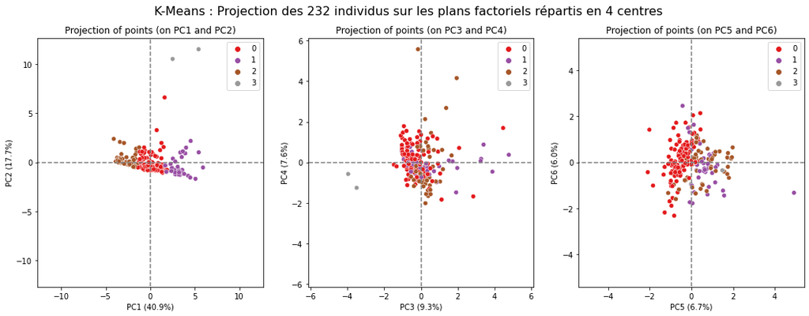

```python
# parametrage des coordonnées des centroïdes sur les data PCA
centroid = km.cluster_centers_
centroid_projected_km = pca.transform(centroid)

# affichage du clustering par projection des individus sur les plans factoriels définis par la PCA
display_factorial_planes(X_projected, 6, pca, [(0,1), (2,3), (4,5)], illustrative_var = 'KMeans', alpha = 0.8)
```

### 5.1.2. HAC

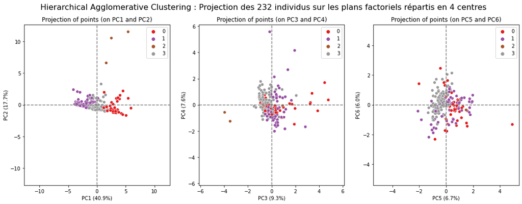

```python
#extraire le moyennes de chaque groupe pour calculer les centroïds
centroid_hac = X_scaled_clustered.groupby(by="cluster_HAC").mean().iloc[:,:-1].to_numpy()

# parametrage des coordonnées des centroïdes sur les data PCA
centroid_projected_hac = pca.transform(centroid_hac)

# affichage du clustering par projection des individus sur les plans factoriels définis par la PCA
display_factorial_planes(X_projected, 6, pca, [(0,1), (2,3), (4,5)], illustrative_var = 'HAC', alpha = 0.8)
```

## 5.2. Composition des clusters

### 5.2.1. K-Means

```python
# Comptage du nombre d'invidus par cluster
from collections import Counter
x = Counter(km.labels_)

#Analyse des clusters
print(f"Nombre d'individus dans chaque cluster : {sorted(x.items())}")
```

```
Nombre d'individus dans chaque cluster : [(0, 134), (1, 41), (2, 55), (3, 2)]
```

### 5.2.2. HAC

```python
# Comptage du nombre d'invidus par cluster
x = Counter(hc.labels_)

#Analyse des clusters
print(f"Nombre d'individus dans chaque cluster : {sorted(x.items())}")
```

```
Nombre d'individus dans chaque cluster : [(0, 43), (1, 65), (2, 3), (3, 121)]
```

## 5.3. Étude des coordonnées des centroïds sur les composantes principales

[figure not shown]

```python
# Représentation des centroids sur le premier plan factoriel

c_km=pd.DataFrame(centroid_projected_km, index=['km_centroid_'+str(i) for i in range(0,4)],
                  columns=['PC%s' % _ for _ in range(1,7)])

c_hc=pd.DataFrame(centroid_projected_hac, index=['hc_centroid_'+str(i) for i in range(0,4)],
                  columns=['PC%s' % _ for _ in range(1,7)])


fig = plt.figure(figsize=(18, 10))
ax1 = fig.add_subplot(231)
sns.scatterplot(ax=ax1, x=c_km.iloc[:, 0], y=c_km.iloc[:, 1], hue=c_km.index, marker='X', s=100)
ax1.plot([-4, 5], [0, 0], color='grey', ls='--')
ax1.plot([0, 0], [-1, 10], color='grey', ls='--')
ax1.set_xticks(range(-4, 6))
ax1.legend()
ax1.set_title('1er plan factoriel : Centroids du KMeans')

ax3 = fig.add_subplot(232)
sns.scatterplot(ax=ax3, x=c_km.iloc[:, 2], y=c_km.iloc[:, 3], hue=c_km.index, marker='X', s=100)
ax3.plot([-4, 5], [0, 0], color='grey', ls='--')
ax3.plot([0, 0], [-1, 10], color='grey', ls='--')
ax3.set_xticks(range(-4, 6))
ax3.legend()
ax3.set_title('2e plan factoriel : Centroids du KMeans')

ax5 = fig.add_subplot(233)
sns.scatterplot(ax=ax5, x=c_km.iloc[:, 4], y=c_km.iloc[:, 5], hue=c_km.index, marker='X', s=100)
ax5.plot([-4, 5], [0, 0], color='grey', ls='--')
ax5.plot([0, 0], [-5, 10], color='grey', ls='--')
ax5.set_xticks(range(-4, 6))
ax5.legend()
ax5.set_title('3e plan factoriel : Centroids du KMeans')

ax2 = fig.add_subplot(234)
sns.scatterplot(ax=ax2, x=c_hc.iloc[:, 0], y=c_hc.iloc[:, 1], hue=c_hc.index, marker='X', s=100)
ax2.plot([-4, 5], [0, 0], color='grey', ls='--')
ax2.plot([0, 0], [-1, 10], color='grey', ls='--')
ax2.set_xticks(range(-4, 6))
ax2.set_title('1er plan factoriel : Centroids du HAC')

ax4 = fig.add_subplot(235)
sns.scatterplot(ax=ax4, x=c_hc.iloc[:, 2], y=c_hc.iloc[:, 3], hue=c_hc.index, marker='X', s=100)
ax4.plot([-4, 5], [0, 0], color='grey', ls='--')
ax4.plot([0, 0], [-1, 10], color='grey', ls='--')
ax4.set_xticks(range(-4, 6))
ax4.set_title('2e plan factoriel : Centroids du HAC')

ax6 = fig.add_subplot(236)
sns.scatterplot(ax=ax6, x=c_hc.iloc[:, 4], y=c_hc.iloc[:, 5], hue=c_hc.index, marker='X', s=100)
ax6.plot([-4, 5], [0, 0], color='grey', ls='--')
ax6.plot([0, 0], [-5, 10], color='grey', ls='--')
ax6.set_xticks(range(-4, 6))
ax6.set_title('2e plan factoriel : Centroids du HAC')

fig.suptitle("Comparaison de la position des 4 centroïds selon les 2 méthodes de clustering", fontsize=18, y=.95)
plt.show()
```

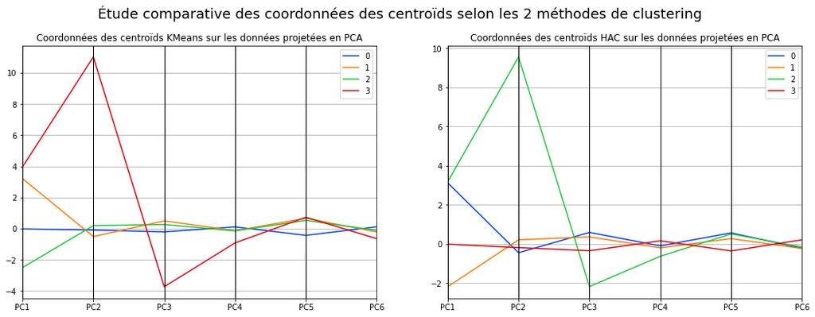

```python
# DataFrame avec les coordonées des centroïds du KMEANS projetés sur les PCA
# centroid_projected_km = pca.transform(km.cluster_centers_)
centr_projected_km = pd.DataFrame(centroid_projected_km, columns=df_clustered.iloc[:,:-2].columns)
centr_projected_km['cluster_KMeans'] = centr_projected_km.index

# DataFrame avec les coordonées des centroïds du HAC projetés sur les PCA
# centroid_projected_hac = pca.transform(centroid_hac)
centr_projected_hac = pd.DataFrame(centroid_projected_hac, columns=df_clustered.iloc[:,:-2].columns)
centr_projected_hac['cluster_HAC'] = centr_projected_hac.index

# Create the plot
fig, (ax1, ax2) = plt.subplots(1,2, figsize=(18,6))
ax = (ax1, ax2)
fig.suptitle("Étude comparative des coordonnées des centroïds selon les 2 méthodes de clustering", fontsize=18, y=1)

# Draw the chart
from pandas.plotting import parallel_coordinates
palette = sns.color_palette("bright", 10)
parallel_coordinates(centr_projected_km, 'cluster_KMeans', color=palette, ax=ax1)
ax1.set_title('Coordonnées des centroïds KMeans sur les données projetées en PCA')

parallel_coordinates(centr_projected_hac, 'cluster_HAC', color=palette, ax=ax2)
ax2.set_title('Coordonnées des centroïds HAC sur les données projetées en PCA')
plt.show()
```

# 6. Analyse des résultats et choix des pays

Les deux méthodes de clustering (K-Means et HAC) offre des clusters quasi identiques dont les centroïds disposent relativement des mêmes coordonnées sur les variables du dataset. En revanche le nombre d'individus par cluster différe d'une méthode à l'autre.

Nous souhaitons sélectionner des pays qui sont en demande (importation forte) et stables. Avec l'analyse des composantes principales, nous avons identifié que la composante PC6 correspondait aux Pays qui importent le plus et qui sont stables : on sélectionnera donc le cluster n°0 du K-Means ou le n°3 du HAC.

```python
print("Nombre d'individus appartenant au cluster n°0 du K-Means :", df_clustered[df_clustered['cluster_KMeans'] == 0].shape[0])
print("Nombre d'individus appartenant au cluster n°3 du HAC :", df_clustered[df_clustered['cluster_HAC'] == 3].shape[0])

k_0 = df_clustered[df_clustered['cluster_KMeans'] == 0].reset_index()['Zone'].to_list()
h_3 = df_clustered[df_clustered['cluster_HAC'] == 3].reset_index()['Zone'].to_list()

print('\n','-'*50,'\n')
print('Liste des individus du cluster K-Means n°0 :\n',k_0)
print('-'*50,'\n')
print('Liste des individus du cluster HAC n°3 :\n', h_3)
```

```
Nombre d'individus appartenant au cluster n°0 du K-Means : 134
Nombre d'individus appartenant au cluster n°3 du HAC : 121

 --------------------------------------------------

Liste des individus du cluster K-Means n°0 :
 ['Afrique du Sud', 'Albanie', 'Algérie', 'Anguilla', 'Antigua-et-Barbuda', 'Antilles néerlandaises (ex)', 'Argentine', 'Arménie', 'Aruba', 'Azerbaïdjan', 'Bahamas', 'Barbade', 'Belize', 'Bhoutan', 'Bolivie (État plurinational de)', 'Bosnie-Herzégovine', 'Botswana', 'Bulgarie', 'Bélarus', 'Cabo Verd…
--------------------------------------------------

Liste des individus du cluster HAC n°3 :
 ['Afrique du Sud', 'Albanie', 'Algérie', 'Anguilla', 'Antigua-et-Barbuda', 'Antilles néerlandaises (ex)', 'Argentine', 'Arménie', 'Azerbaïdjan', 'Bahamas', 'Barbade', 'Belize', 'Bhoutan', 'Bolivie (État plurinational de)', 'Bosnie-Herzégovine', 'Botswana', 'Bulgarie', 'Bélarus', 'Cabo Verde', 'Chil…
```

```python
# Liaison des composantes principales avec les valeurs des 5 pays les mieux représentées positivement
for PC in PC_pays.columns:
    PC_pays_list_pos = PC_pays[PC].sort_values(ascending=False).head(5)

    print('Liste des 5', PC, ': \n',PC_pays_list_pos, "(valeurs): \n", '-'*50, '\n')
```

```
Liste des 5 Pays riches, stables et urbains :
 Zone
Canada                      5.916427
Chine - RAS de Hong-Kong    5.433219
États-Unis d'Amérique       5.416828
Chine - RAS de Macao        5.071112
Pays-Bas                    4.532213
Name: Pays riches, stables et urbains, dtype: float64 (valeurs):
 --------------------------------------------------

Liste des 5 Pays producteurs et exportateurs :
 Zone
États-Unis d'Amérique    11.521990
Brésil                   10.529936
Chine, continentale       6.609401
Chine                     3.281888
Burundi                   2.394003
Name: Pays producteurs et exportateurs, dtype: float64 (valeurs):
 --------------------------------------------------

Liste des 5 Pays importateurs mais peu stables :
 Zone
Japon                       4.787298
Mexique                     4.474694
Arabie saoudite             3.892190
Chine - RAS de Hong-Kong    3.412325
Allemagne                   3.279417
Name: Pays importateurs mais peu stables, dtype: float64 (valeurs):
 --------------------------------------------------

Liste des 5 Pays à forte inflation :
 Zone
Suriname        5.580932
Angola          4.157761
Burundi         2.683804
Sierra Leone    2.134253
Argentine       1.785829
Name: Pays à forte inflation, dtype: float64 (valeurs):
 --------------------------------------------------

Liste des 5 Pays avec des crédits pour l'agriculture mais peu d'accès à l'eau :
 Zone
Canada        4.920261
Rwanda        1.976720
Niger         1.941401
Madagascar    1.905644
Angola        1.795680
Name: Pays avec des crédits pour l'agriculture mais peu d'accès à l'eau, dtype: float64 (valeurs):
 --------------------------------------------------

Liste des 5 Pays importateurs et stables :
 Zone
Japon                            2.457816
Micronésie (États fédérés de)    2.140728
Samoa                            2.047649
Tonga                            1.725660
Viet Nam                         1.722483
Name: Pays importateurs et stables, dtype: float64 (valeurs):
 --------------------------------------------------
```